# Task 1 - Principal component analysis

Max Settineri

2023-02-28

## Introduction

This analysis examines miscellaneous environmental and climatic variables by country compiled by @zander_venter on Kaggle. A principle component analysis will be conducted on variables of interest to assess relationships between variables. A screeplot will also be used to examine variance explained by individual principle components.

**Data** compiled and provided by @zander_venter on Kaggle, described as: “This data is all acquired through Google Earth Engine (https://earthengine.google.com/) where publicly available remote sensing datasets have been uploaded…Most of the data is derived by calculating the mean for each country at a reduction scale of about 10km.”

## PCA

```r
## reading in the data
environmental <- read_csv(here('data/world_env_vars.csv')) %>%
  drop_na() %>%
  clean_names() %>%
  select(accessibility_to_cities, elevation, cropland_cover, tree_canopy_cover, rain_mean_annual, rain_seasonailty, temp_annual_range, temp_mean_annual, wind, cloudiness) %>%
  rename('Accessibility to cities' = accessibility_to_cities,
         'Elevation' = elevation,
         'Cropland cover' = cropland_cover,
         'Tree canopy cover' = tree_canopy_cover,
         'Mean annual rainfall' = rain_mean_annual,
         'Rain seasonality' = rain_seasonailty,
         'Annual temperature range' = temp_annual_range,
         'Mean annual temperature' = temp_mean_annual,
         'Wind' = wind,
         'Cloudiness' = cloudiness
         )


environmental_pca <- environmental %>%
  scale() %>% ## scaling data to one standard deviation
  prcomp() ## running the PCA
```

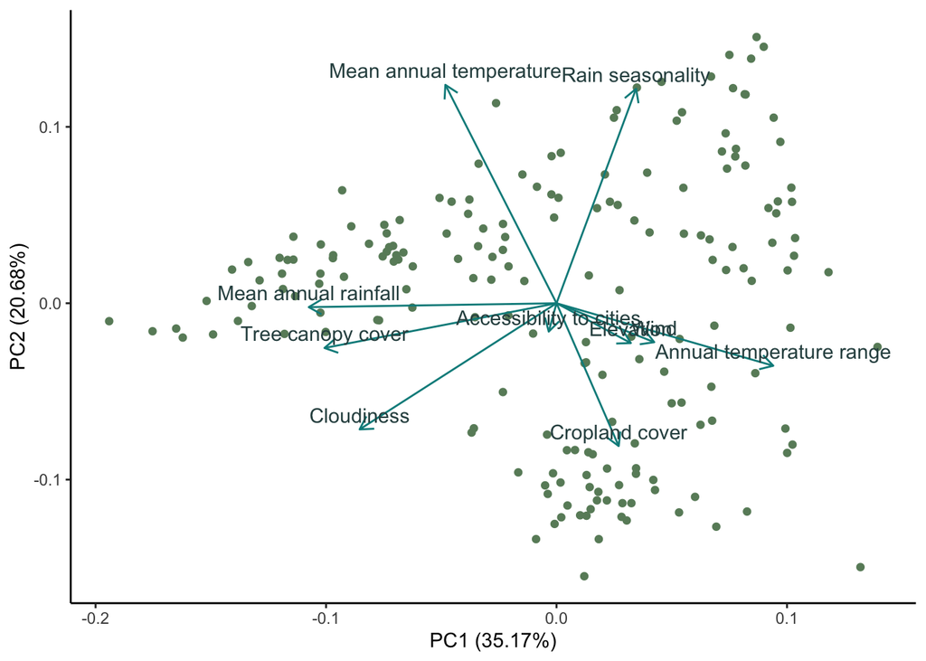

```r
## plotting the PCA
autoplot(environmental_pca,
        data = environmental,
        loadings = TRUE,
        colour = 'darkseagreen4',
        loadings.label = TRUE,
        loadings.colour = 'darkcyan',
        loadings.label.colour = 'darkslategray',
        loadings.label.vjust = -0.5) +
  theme_classic()
```

**Figure 1** displays a biplot with results from our principle component analysis. Arrow length represents the proportion of variance that is explained by a given principle component. Each point represents one of the 188 countries incorporated in this analysis.

## Screeplot

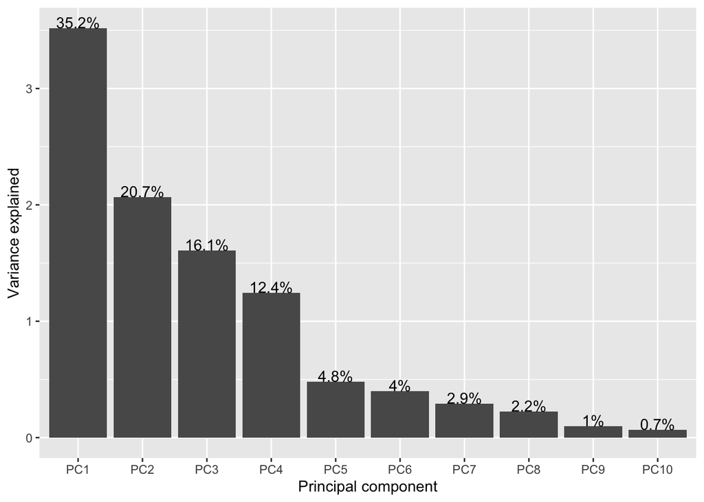

```r
sd_vec <- environmental_pca$sdev ## extracting sd for each pc
var_vec <- sd_vec^2 ## calculating variance of each pc by squaring the sd of each pc
pc_names <- colnames(environmental_pca$rotation) ## pulling names of each pc

## creating data frame with the variance of each pc
pct_expl_df <- data.frame(v = var_vec,
                          pct_v = var_vec / sum(var_vec),
                          pc = fct_inorder(pc_names)) %>%
  mutate(pct_lbl = paste0(round(pct_v * 100, 1), '%'))

## creating screeplot
ggplot(pct_expl_df, aes(x = pc, y = v)) + ## mapping pc to the x axis and variance to the y
  geom_col() +
  geom_text(aes(label = pct_lbl), vjust = 0, nudge_y = .002) +
  labs(x = 'Principal component', y = 'Variance explained')
```

**Figure 2** shows a screeplot displaying variance explained by individual principle components.

## Summary

- Cropland cover and mean annual temperature show a high negative correlation, highlighting the importance of appropriate climate for agricultural production
- Mean annual rainfall and tree canopy cover are highly positively correlated, indicating that trees grow well in areas with higher precipitation
- Mean annual temperature and elevation show a negative correlation, as higher elevations generally have lower temperatures
- Cloudiness and mean annual temperature show almost no correlation
- As demonstrated in figure 2, four principle components explain over 80% of the variance. The argument could be made the PC1-4 are sufficient to analyze variance between countires.